# Customer Loyalty and Purchase History

Proposal Presentation

Sora Hosoda

IBM 6540, Cal Poly Pomona

2026-07-07

# Introduction

## Problem Statement

Digital marketing campaigns are designed to encourage customers to take a desired action.

Customer loyalty and previous purchase behavior may be related to whether a customer converts after a marketing campaign.

Understanding these relationships can help marketers identify customer behaviors that are connected with conversion.

## Analytics Objective

> **To examine whether customer loyalty and previous purchase behavior influence the likelihood of customer conversion.**

**Independent Variables (IVs):**

- `PreviousPurchases`
- `LoyaltyPoints`

**Dependent Variable (DV):**

- `Conversion`

## Importance

- Understanding customer loyalty and purchase history may help identify customers who are more likely to convert.
- The findings can help marketers better understand customer behavior and support marketing decisions.

# Methods

## Data and Sampling

- **Dataset:** Predict Conversion in Digital Marketing Dataset
- **Rows:** 8,000 customer records
- **Columns:** 20 variables
- **Target variable:** `Conversion`
- **Data type:** Synthetic digital marketing campaign data
- **Unit of analysis:** Individual customer

## Data Wrangling

- Check missing values in `PreviousPurchases`, `LoyaltyPoints`, and `Conversion`.
- Convert `Conversion` into a categorical variable.
- Check duplicate records.
- Examine distributions and potential outliers.

## Sample Characteristics

The dataset contains 8,000 individual customer records.

For this analytics objective, the analysis focuses on:

- `PreviousPurchases`
- `LoyaltyPoints`
- `Conversion`

## Measures

| Construct | Variable | Role |
| --- | --- | --- |
| Previous purchase behavior | `PreviousPurchases` | Independent Variable |
| Customer loyalty | `LoyaltyPoints` | Independent Variable |
| Customer conversion | `Conversion` | Dependent Variable |

## Reproducible Visualization

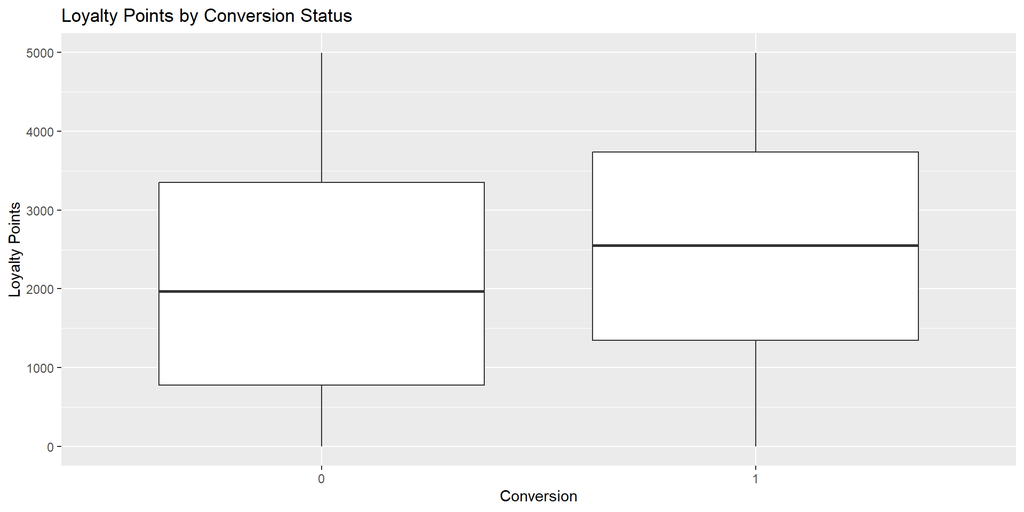

Figure 1: Loyalty Points by Conversion Status

## Analytics Methods

The analysis will begin with descriptive statistics and visualizations.

**Planned visualizations:**

- Boxplot of `LoyaltyPoints` by conversion status
- Boxplot of `PreviousPurchases` by conversion status
- Scatterplot of `PreviousPurchases` and `LoyaltyPoints`
- Correlation heatmap of key variables

# References

- [Predict Conversion in Digital Marketing Dataset - Kaggle](https://www.kaggle.com/datasets/rabieelkharoua/predict-conversion-in-digital-marketing-dataset)
- [Quarto RevealJS Presentation Video](https://youtu.be/vjL-BIJenBI?si=vbyD2_vB8m0LiwaE)